# BivData Setup

April Peterson

12 May 2020

# Main Files

Main files from this Script:

1. **Curated_BIVDATA**: cleaned up version of the passing, curated Bivalent measures
2. **Foci_TRUE_Curated_Bivdata**: filterd version of the Curated_BivData file, but with only measures that have ‘good’ foci position information
3. OG.Curate_FULL: original version of the Bivalent data (before ‘failed’ SC wiped away)
4. **MELT_ABS**: make melt version of foci positions for abs measuers
5. **Strain DFs** for Het models **Mouse.Table_BivData_4MM**
6. **male Subsp DFs** for Polymorphism models **Male.poly.Mouse.Table_BivData_4MM**

files that will be made in setup 5. CELL level table (full all mice) (use this to make long biv dataset)

6. Long Biv Dataset and short biv dataset
7. mouse table (full all mice)

# Data setup and basic cleaning

- remove BivData! (these are all Peromyscus!!) (not sure where this DF comes from)

add mean.telomere, mean cent.dist and mean sis.coten to the mouse level table

update IFD functions, to add IFD2,3 – report the summaries

format manual data set so SC.length = Chrmlength (matches the bivData)

ToDo

- Fix the hand.foci.count ==2, 5jan19_27oct18_SKIVE_m2_sp1_3.2_rev_13
- Fix all the hand.foci == 4, which don’t have the right number of positions
- Go back and clean up the original excel data
- clean the bottom, fill in missing data
- check the order of foci positions for 5aug17_14jul17_LEW_f1_sp1_11_rev_blob4.

edit / clean up the lines with bad hand.foci.count (61)

ToDo:

1.clean up the non-numbered curated values (for the og df)

2.Goal of this doc is to make DFs that are ready for the analysis.

3.remove the 2 main sources of duplicate lines; 6mar16_PWD_m1, 1mar15_PWD_m1

4. decide on the right number of passing curated bivalents per category I should settle for Justify why the current number is enough – or subsample – to random equivilent sized data sets
5. make sure that the saved Rdata has all the right cols and tables for the next analyses
6. consider integrating manual hand / whole cell measures (check for DUPs ect.)

Curated_BivData will be the master DF with most observations. DFs for mixed models and tests need to subsetted from this one.

```
## [1] 5335
```

Duplicates removed, 171. most were MSM and PWD males.

399 rows removed for excluded mice.

after all of these chunks are run, save the excel file for Curated_BivData

DUPs, negative IFDs, remove juvi and MLH1 exclude mice,

There are 3 bivalents with Per.Foci2 > 1 (remove or go correct)

Main files from this Script:

1. **Curated_BIVDATA**: cleaned up version of the passing, curated Bivalent measures
2. **Foci_TRUE_Curated_Bivdata**: filterd version of the Curated_BivData file, but with only measures that have ‘good’ foci position information
3. OG.Curate_FULL: original version of the Bivalent data (before ‘failed’ SC wiped away)
4. **MELT_ABS**: make melt version of foci positions for abs measuers
5. CELL level table (full all mice) (use this to make long biv dataset)
6. Long Biv Dataset
7. mouse table (full all mice)
8. **Strain DFs** for Het models (summary strain DFs and tables?)
9. **Mouse.Table_BivData_4MM** Mouse level table for HetC mixed models
10. **male Subsp DFs** for Polymorphism models **Male.poly.Mouse.Table_BivData_4MM**

I’m considering removing the same mice from the MLH1 counts, from the BivData, but this might – limit the comparisons – might be too stict. IF foci are bright and clear, SC/bivalents intact – include.

If it seems like primary reason for excluding is low cell number include bivalents

Pro remove:

- more similarity across data sets

Con remove:

- the reasons for poor quality of the exclude mice in above list, might be from 2-3 bad bivalents – which are removed from the biv data during the curation process.

## Strain specific BivData sets

Compile dataframes for both sexes of each strain.

```
##
##            0   1   2   3   4  19  24 <NA>
##   female   6 539 187  30   3   1   1  122
##   male    12 472 107   0   1   0   0   33
```

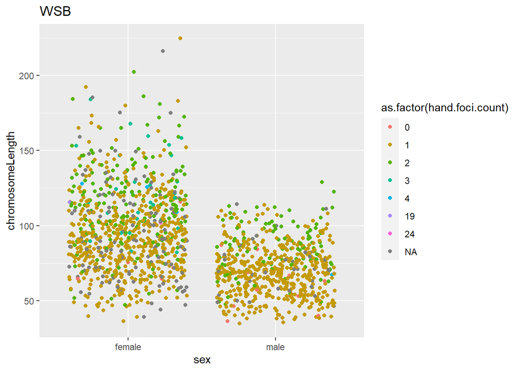

```
##
##            0   1   2   3   4 <NA>
##   female   5 413 236  28   3   52
##   male     6 409 106  10   2   25
```

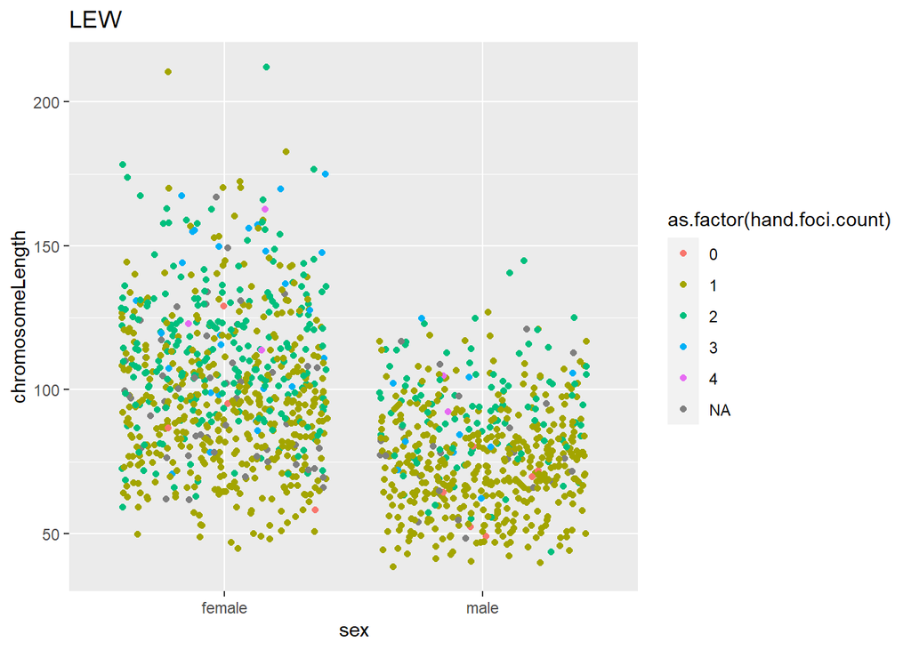

```
##
##            0   1   2   3   4 <NA>
##   female   6 457 242  19   2   40
##   male    14 797 183  10   0   27
```

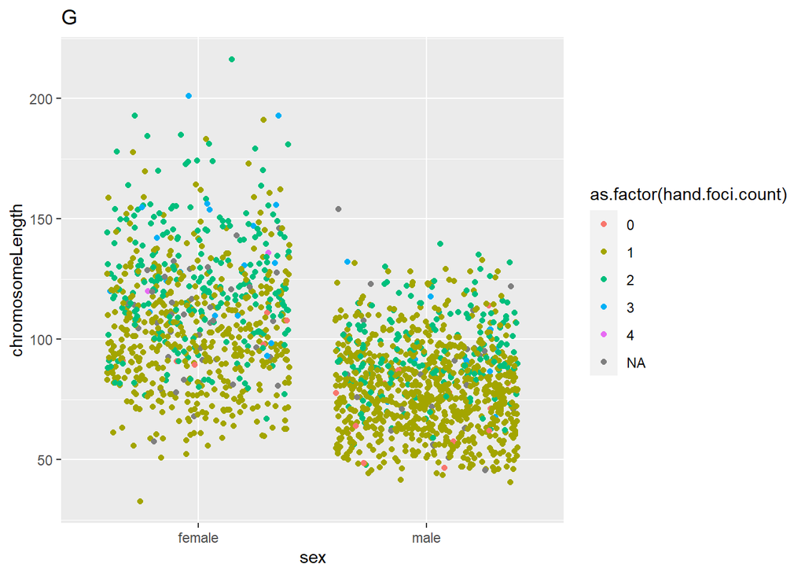

```
##
##            0   1   2   3 <NA>
##   female  10 672 280  36   47
##   male     3 337 274   9   38
```

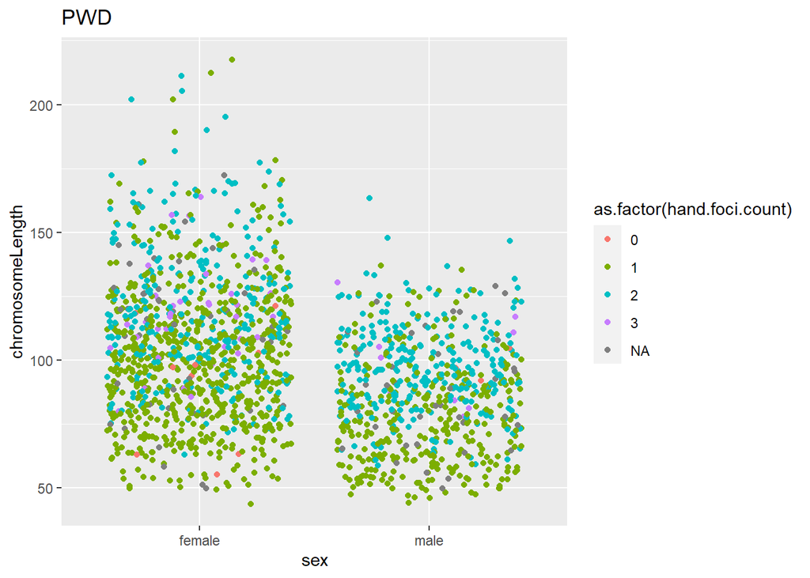

```
##
##            0   1   2   3 <NA>
##   female   1 351 128   5    7
##   male    22 502  84   7  125
```

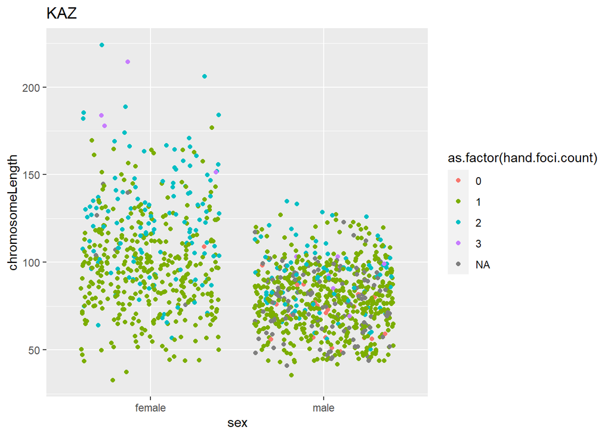

```
##
##            0   1   2   3  22 <NA>
##   female   1 122  42   6   0   11
##   male     6 510 253   6   1   37
```

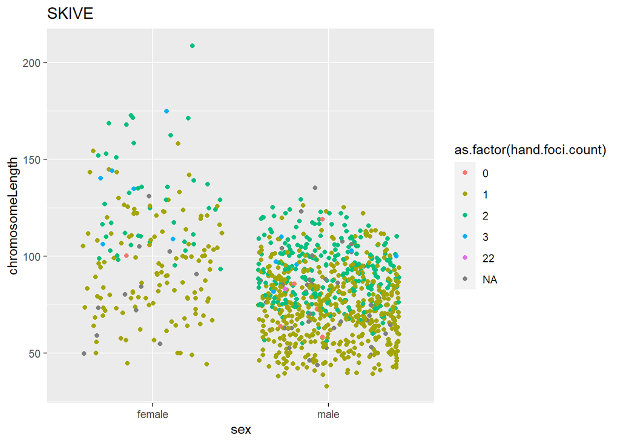

```
##
##            0   1   2   3   4 <NA>
##   female   7 362 159  21   1   13
##   male     0  30  32   1   0    1
```

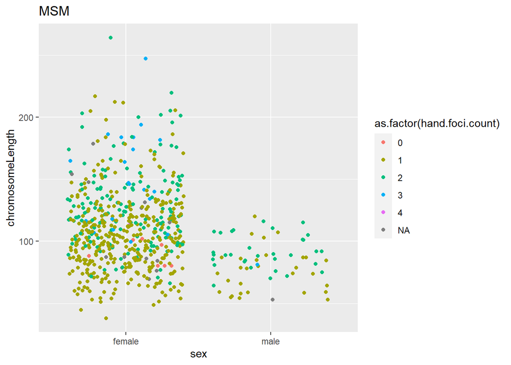

## Male specific BivData set

Redo the plots from above, just male data with strain on the x

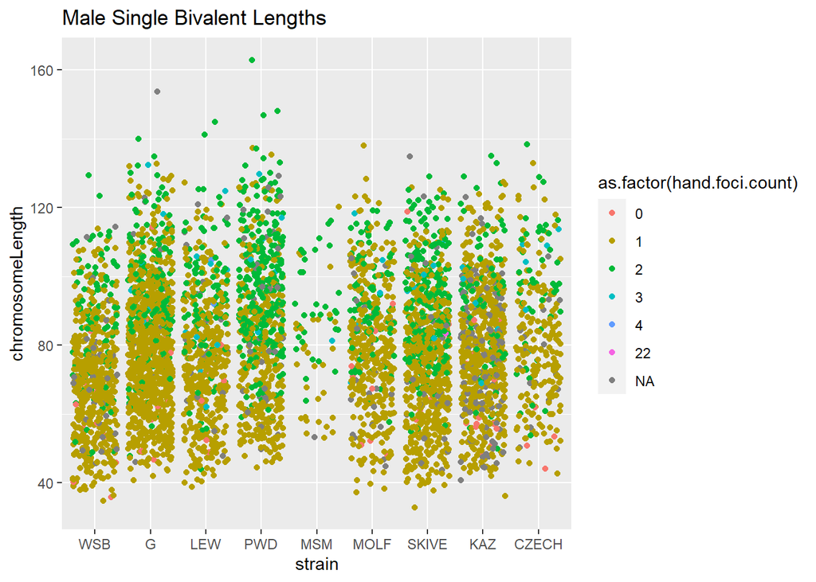

# Manual Whole Cell BivData

Cleaning and integrating the dataframes for manual measured data.

```
##  [1] "return5"         "fileName"        "boxNumber"       "centromere"
##  [5] "SC.length"       "rank"            "chrm.class"      "hand.foci.count"
##  [9] "F1"              "F2"              "F3"              "notes"
## [13] "X"               "X.1"
```

# Cell Level Table

- pass rate (don’t need the OG.DF file, because I can count the number of boxes with the max index number)
- number bivs per mice?
- number cells represented per mouse
- number of pass.SC w/out foci position data
- number of foci with ‘faint’ mentioned in the notes

The below cell level table is used for making the **long.biv.dataset** and short, (any others?)

3 cells have manual measures and BivData measures. test error, need to match them up. There are 145 cells from the BivData set which are close to whole cells.  
8jun15_23apr15_PWD_f2_sp1_20_rev, 29nov16_13nov16_MSM_m2_sp1_13_rev, 27oct16_31aug16_MSM_m1_sp1_9_rev

# Long and Short BivData Set

I want to make a dataset of ‘longest’ 25% chromosomes from cells with at least 16 segmented bivalents from a single cell.

The above blocks of code 1) isolates bivalents measures from cells with >15 segmented bivalents 2) for the cells in these data calculates the Q4 threshold and 3) marks which bivalents are longer than the threshold.

The above code chunk makes 2 mouse level tables; **Long.biv_mouse_table_HetC** and **Long.biv_mouse_table_male.poly**. Run these through the model systems.

# Mouse Level Tables

Mouse level tables are the main meat of the models. There will be several for use in different models. Format these tables for run the mixed models (unordered factors, ect).

analysis using the mouse level table – to justify that using mouse averages is a good idea.

# Melt Position Table

The BivData MELT DF is primarily for the nrmF1.pos plots/analysis. It is a Melted DF for raw and normalized foci positions from the Curated_BivData.

# Assemble Final BivData DF

Main files from this Script:

1. **Curated_BIVDATA**: cleaned up version of the passing, curated Bivalent measures
2. **Foci_TRUE_Curated_Bivdata**: filterd version of the Curated_BivData file, but with only measures that have ‘good’ foci position information
3. OG.Curate_FULL: original version of the Bivalent data (before ‘failed’ SC wiped away)
4. **MELT_ABS**: make melt version of foci positions for abs measuers
5. CELL level table (full all mice) (use this to make long biv dataset)
6. Long Biv Dataset
7. mouse table (full/all mice)
8. **Strain DFs** for Het models **Mouse.Table_BivData_4MM**
9. **male Subsp DFs** for Polymorphism models **Male.poly.Mouse.Table_BivData_4MM**

MAIN BIVDATA_DF decide on the colnames that I want for the final DF

fileName, Object_ID, box.number, centromere_ABS, centromere_PER chromosome length, SC.pass, Foci.pass, hand.foci.count, F1, F2, F3, F4, F1_per, F2_per, F3_per, F4_per, IFD

telomere_dist, cent_dist,

mouse, strain, category, subsp,

merge: cell.MLH1.count, cell.quality, mouse.age, cell.total_skel, cell.total_binary

# Save

```r
#save Rdata
save.image("~./MLH1repo/data/CleanBivData_5.12.20.RData")
#save.image("data/BivData_4_PCA.RData")
```

# Analysis

planned analyses for later docs, but this is the list for getting everything ready

Use the Bivalent_Analysis.Rmd for analysis pieces BivPattern.Rmd started to analyze this but, not a very clear setup

-chrom class proportions

-SC lengths, by CO number